# Homework 1

2020-03-31

```r
knitr::opts_chunk$set(echo = TRUE)

# Load libraries for homework problems
library(gapminder) # for data
library(ggplot2)   # for graphs
library(readr)     # for reading in solutions
library(gganimate) # for animation
library(gifski)    # for animation
```

# Problem 1

We will be using a curated version of the `gapminder` dataset.

1. Create a logical vector using `gapminder` that is `TRUE` if `gapminder$year` is equal to 2007 and `FALSE` otherwise.
2. Use the vector to create a subset of the gapminder data, containing only the rows from the year 2007. Call this subset of data `gapminder_2007`

**Note**: If you get stuck on this problem, you can proceed to the next problems using the `gapminder_2007` object produced by the solution code below.

Your 2007 data should look like this:

```r
gapminder_2007 <- read_rds('solutions/01_solution.rds')

gapminder_2007
```

| country | continent | year | lifeExp | pop | gdpPercap |
| --- | --- | --- | --- | --- | --- |
| Afghanistan | Asia | 2007 | 43.828 | 31889923 | 974.5803 |
| Albania | Europe | 2007 | 76.423 | 3600523 | 5937.0295 |
| Algeria | Africa | 2007 | 72.301 | 33333216 | 6223.3675 |
| Angola | Africa | 2007 | 42.731 | 12420476 | 4797.2313 |
| Argentina | Americas | 2007 | 75.320 | 40301927 | 12779.3796 |
| Australia | Oceania | 2007 | 81.235 | 20434176 | 34435.3674 |
| Austria | Europe | 2007 | 79.829 | 8199783 | 36126.4927 |
| Bahrain | Asia | 2007 | 75.635 | 708573 | 29796.0483 |
| Bangladesh | Asia | 2007 | 64.062 | 150448339 | 1391.2538 |
| Belgium | Europe | 2007 | 79.441 | 10392226 | 33692.6051 |

[output cut: 132 more lines]

# Problem 2

Create a plot using the `ggplot2` package:

- use the `ggplot()` function and specify `data = gapminder_2007`.
- use the `aes()` function:
  - y axis should be `lifeExp` (life expectancy)
  - x axis should be `gdpPercap` (gross domestic product per capita; a measure of income)
  - the `fill` of objects plotted should correspond with `continent` values.
  - the `size` of objects plotted should correspond with `pop` values.
- use `geom_point(shape = 21)` to get points with visible fill colors.
- adjust the x-axis to be on the log 10 scale.

The finished figure will look like this:

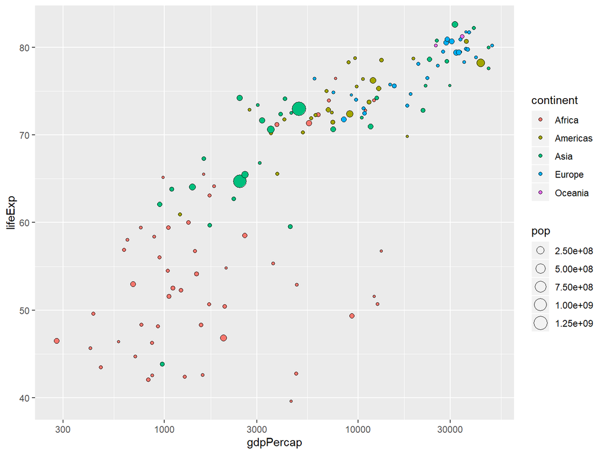

```r
read_rds('solutions/02_solution.rds')
```

# Problem 3

Make some aesthetic changes to the figure.

- add labels to the fill, scale, title, subtitle, and axes of the figure.
- use a `theme_()` function of your choice. (mine is `theme_minimal()`)
- use the `theme()` function to increase the size of all text in the plot.

The finished figure will look like this:

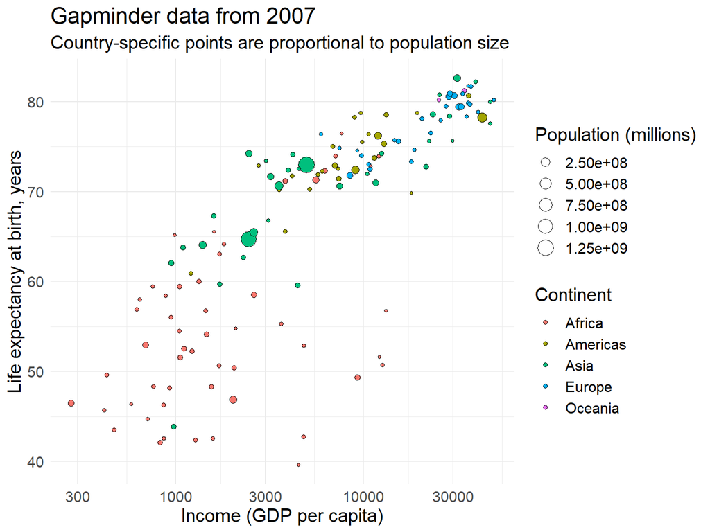

```r
read_rds('solutions/03_solution.rds')
```

# Problem 4

Make a couple more adjustments to the figure:

- Remove the point size guideline from the legend.
- Increase the size of points in the fill portion of the legend. (hint: look up `guides`)

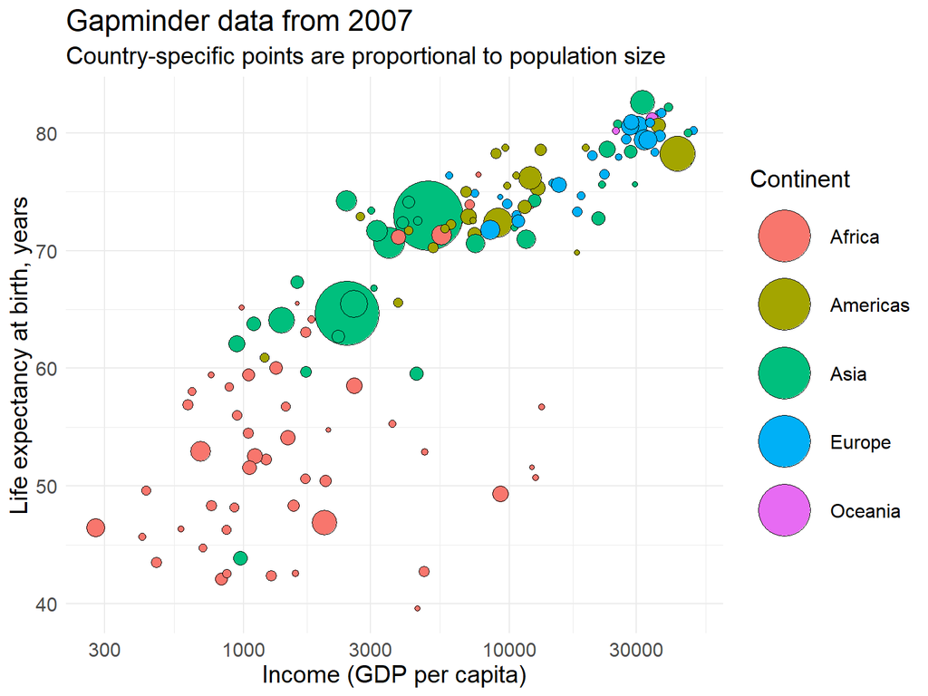

```r
read_rds('solutions/04_solution.rds')
```

# Problem 5

- Re-create the figure from problem 4 using the entire `gapminder` dataset instead of the `gapminder_2007` data.
- Use the `gganimate` package to make a smooth animation that has frames based on the `year` column.

*Notes:*

- You can find a great `gganimate` tutorial [here](https://github.com/thomasp85/gganimate)
- For your own exploration and fun, you can install the `ggrepel` package and try to attach labels to individual countries.

```r
soln <- read_rds('solutions/05_solution.rds')

animate(soln,
  nframes = 250,
  fps = 50,
  width = 96 * 8,
  height = 96 * 6
)
```

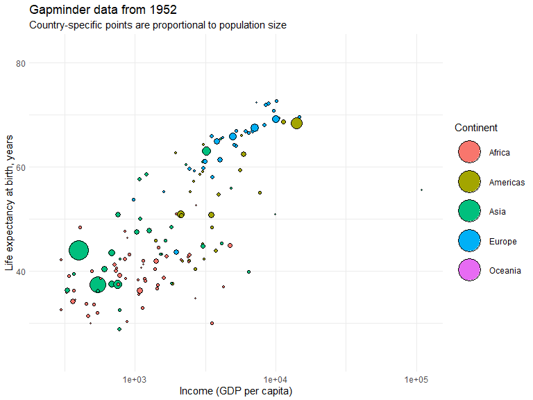